# temp-161539931623606864

1. Introdução
2. Avaliação inicial das informações contidas nas features
   1. Seleção das colunas que serão utilizadas na modelagem:
   2. Pré-processamento para a coluna de 'amenities'
   3. Pré-processamento para a coluna de 'neighbourhood_cleansed'
   4. Pré-processamento para a coluna de 'property_type'
   5. Pré-processamento para a coluna de 'bathrooms_text'
3. Funções de pré-processamento
4. Pré-processamento dos dados e preparação para análises
5. Separação de treino e teste, e tratamento de missings
6. Modelagem
   1. Analises de PCA
   2. Modelo 1: LinearRegression
   3. Modelo 2: SVM
   4. Modelo 3: Kernel Ridge
   5. Modelo 4: XGBoost
7. Analises de residuos
8. Comparação das métricas dos modelos e conclusão

## Introdução

No presente desafio será desenvolvido um modelo preditivo para precificação de locações via Arbnb, utilizando dados de fevereiro de 2021 correspondentes as locações disponíveis no Rio de Janeiro. A fonte de dados foi extraída deste link: http://insideairbnb.com/get-the-data.html.

Para este desafio foram utilizadas as informações de fevereiro de 2021. No arquivo '.csv', são encontradas 74 colunas. Algumas contem texto, valores booleanos e valores numéricos. A primeira tarefa que será realizada é uma análises rápida do conteúdo de cada coluna e a viabilidade de inclusão da mesma no modelo. Mas antes disso são importadas as bibliotecas uteis no desenvolvimento do modelo. Além de carregar os dados num dataframe.

```python
import pandas as pd
import numpy as np
import ast
import matplotlib.pyplot as plt
%matplotlib inline
from sklearn.model_selection import train_test_split
from sklearn.impute import SimpleImputer
from sklearn.preprocessing import StandardScaler
from sklearn.pipeline import Pipeline
from sklearn.decomposition import PCA
from sklearn.linear_model import *
from sklearn.metrics import r2_score
from sklearn.svm import SVR
from sklearn.model_selection import GridSearchCV
from xgboost import XGBRegressor
from seaborn import residplot
from sklearn.metrics import *
```

```python
df_main=pd.read_csv('listings.csv',sep=',',encoding='utf8')
df_main
```

|  | id | listing_url | scrape_id | last_scraped | name | description | neighborhood_overview | picture_url | host_id | host_url | ... | review_scores_communication | review_scores_location | review_scores_value | license | instant_bookable | calculated_host_listings_count | calculated_host_listings_count_entire_homes | calculated_host_listings_count_private_rooms | calculated_host_listings_count_shared_rooms | reviews_per_month |
| --- | --- | --- | --- | --- | --- | --- | --- | --- | --- | --- | --- | --- | --- | --- | --- | --- | --- | --- | --- | --- | --- |
| 0 | 17878 | https://www.airbnb.com/rooms/17878 | 20210222161029 | 2021-02-23 | Very Nice 2Br in Copacabana w. balcony, fast WiFi | Discounts for long term stays. <br />- Large b... | This is the one of the bests spots in Rio. Bec... | https://a0.muscache.com/pictures/65320518/3069... | 68997 | https://www.airbnb.com/users/show/68997 | ... | 10.0 | 10.0 | 9.0 | NaN | t | 1 | 1 | 0 | 0 | 2.01 |
| 1 | 24480 | https://www.airbnb.com/rooms/24480 | 20210222161029 | 2021-02-23 | Nice and cozy near Ipanema Beach | My studio is located in the best of Ipanema. ... | The beach, the lagoon, Ipanema is a great loca... | https://a0.muscache.com/pictures/11955612/b28e... | 99249 | https://www.airbnb.com/users/show/99249 | ... | 10.0 | 10.0 | 9.0 | NaN | f | 1 | 1 | 0 | 0 | 0.67 |
| 2 | 25026 | https://www.airbnb.com/rooms/25026 | 20210222161029 | 2021-02-23 | Beautiful Modern Decorated Studio in Copa | Our apartment is a little gem, everyone loves ... | Copacabana is a lively neighborhood and the ap... | https://a0.muscache.com/pictures/3003965/68ebb... | 3746246 | https://www.airbnb.com/users/show/3746246 | ... | 10.0 | 10.0 | 9.0 | NaN | f | 11 | 11 | 0 | 0 | 1.82 |
| 3 | 35636 | https://www.airbnb.com/rooms/35636 | 20210222161029 | 2021-02-24 | Cosy flat close to Ipanema beach | This cosy apartment is just a few steps away ... | The apartment street is very quiet and safe .... | https://a0.muscache.com/pictures/20009355/38b6... | 153232 | https://www.airbnb.com/users/show/153232 | ... | 10.0 | 10.0 | 9.0 | NaN | f | 1 | 1 | 0 | 0 | 2.02 |
| 4 | 35764 | https://www.airbnb.com/rooms/35764 | 20210222161029 | 2021-02-23 | COPACABANA SEA BREEZE - RIO - 20 X Superhost | Our newly renovated studio is located in the b... | Our guests will experience living with a local... | https://a0.muscache.com/pictures/23782972/1d3e... | 153691 | https://www.airbnb.com/users/show/153691 | ... | 10.0 | 10.0 | 10.0 | NaN | f | 1 | 1 | 0 | 0 | 2.79 |
| ... | ... | ... | ... | ... | ... | ... | ... | ... | ... | ... | ... | ... | ... | ... | ... | ... | ... | ... | ... | ... | ... |
| 26610 | 48269503 | https://www.airbnb.com/rooms/48269503 | 20210222161029 | 2021-02-24 | Quarto inteiro no Recreio dos Bandeirantes. | NaN | NaN | https://a0.muscache.com/pictures/8d90763a-8aac... | 389246322 | https://www.airbnb.com/users/show/389246322 | ... | NaN | NaN | NaN | NaN | f | 4 | 0 | 4 | 0 | NaN |
| 26611 | 48269534 | https://www.airbnb.com/rooms/48269534 | 20210222161029 | 2021-02-24 | Casa grande mobiliada, 2 quartos em Jacarepaguá. | Nossa casa totalmente mobiliada está localizad... | Conheça um pouquinho da zona oeste do Rio de J... | https://a0.muscache.com/pictures/54e06fdd-b88b... | 122122028 | https://www.airbnb.com/users/show/122122028 | ... | NaN | NaN | NaN | NaN | t | 1 | 1 | 0 | 0 | NaN |
| 26612 | 48270411 | https://www.airbnb.com/rooms/48270411 | 20210222161029 | 2021-02-24 | BR-RJ020 Casa Niemeyer vista deslumbrante | Uma vista deslumbrante de toda praia de são Co... | O bairro é muito bem localizado próximo à prai... | https://a0.muscache.com/pictures/8cc66765-57fd... | 13773093 | https://www.airbnb.com/users/show/13773093 | ... | NaN | NaN | NaN | NaN | t | 1 | 1 | 0 | 0 | NaN |
| 26613 | 48270514 | https://www.airbnb.com/rooms/48270514 | 20210222161029 | 2021-02-24 | Casa Tijuca - Curtir e aproveitar o Rio | Nossa casa é nosso cantinho quando estamos no ... | A Tijuca é um bairro centenário e acolhedor, ... | https://a0.muscache.com/pictures/4c865b22-baca... | 23737846 | https://www.airbnb.com/users/show/23737846 | ... | NaN | NaN | NaN | NaN | f | 3 | 1 | 2 | 0 | NaN |
| 26614 | 48276004 | https://www.airbnb.com/rooms/48276004 | 20210222161029 | 2021-02-23 | Rio Spot Homes D040 | <b>Other things to note</b><br />Beautiful and... | NaN | https://a0.muscache.com/pictures/7e7a9798-5428... | 13580277 | https://www.airbnb.com/users/show/13580277 | ... | NaN | NaN | NaN | NaN | t | 59 | 58 | 0 | 0 | NaN |

26615 rows × 74 columns

## Avaliação inicial das informações contidas nas features

### Seleção das colunas que serão utilizadas na modelagem:

Para a primeira avaliação foi examinado o conteúdo de cada coluna, foram feitas as seguintes identificações:

- Para um modelo inicial ou para obter informações rapidamente, como no caso de um desafio, devem ser excluídas colunas que contém informações que precisam de tratamentos avançados para serem úteis, como informações textuais de difícil tratamento, sendo consideradas novamente em fases posteriores se for avaliado que a energia investida no tratamento destas informações é compensada pelo aumento significativo nas métricas do modelo pela inclusão da informação. Assim por exemplo, se tivermos um modelo com precisão de 95%, possivelmente um trabalho de meses com NLP para incluir estas informações para chegar a um 97% não seja apropriado, mas sim a precisão antes foi de 50% e se tem uma expectativa de uma melhora para mais de 90% pela inclusão destas informações, então este investimento de tempo e conhecimentos possa ser recomendado. Assim em um analise inicial podemos deixar estes campos mais desafiadores de lado, e avaliar posteriormente a necessidade de voltar neles. Assim foram identificadas as seguintes colunas com informações que não contribuem para o modelo ou que precisariam de um tratamento de NLP para extração de informações:

  [name,description,neighborhood_overview,host_about,host_response_time,host_verifications]
- Também foram excluídas colunas com informações redundantes, nulas ou que claramente não tem influencia significativa na precificação:

  [listing_url,scrape_id,last_scraped,picture_url,host_id,host_url,host_name,host_since,host_location,host_neighbourhood,host_response_rate,host_acceptance_rate,host_thumbnail_url, host_picture_url,host_listings_count,host_total_listings_count,neighbourhood,neighbourhood_group_cleansed,latitude,longitude,bathrooms,calendar_updated,minimum_minimum_nights, maximum_minimum_nights,minimum_maximum_nights,maximum_maximum_nights,minimum_nights_avg_ntm,maximum_nights_avg_ntm,has_availability,availability_30, availability_60,availability_90,availability_365,calendar_last_scraped,number_of_reviews_ltm,number_of_reviews_l30d,first_review,last_review,license,instant_bookable, calculated_host_listings_count,calculated_host_listings_count_entire_homes,calculated_host_listings_count_private_rooms,calculated_host_listings_count_shared_rooms, reviews_per_month]
- Assim as colunas restantes que entraram na versão inicial do modelo são:

```python
columns_model=['id','host_is_superhost','host_has_profile_pic', 'host_identity_verified','neighbourhood_cleansed',  'property_type', 'room_type', 'accommodates',
       'bathrooms_text', 'bedrooms', 'beds', 'amenities', 'price','minimum_nights', 'maximum_nights', 'number_of_reviews','review_scores_rating', 'review_scores_accuracy',
        'review_scores_cleanliness', 'review_scores_checkin', 'review_scores_communication', 'review_scores_location','review_scores_value']
```

Vale também ver um resumo do número de missing e a densidade de missings para estas colunas:

```python
missings=pd.DataFrame((len(df_main[columns_model])-df_main[columns_model].count()),columns=['Missings']).reset_index().rename(columns={'index':'coluna'})
missings['% Percentual Missing']=missings.Missings/len(df_main[columns_model])*100
missings
```

|  | coluna | Missings | % Percentual Missing |
| --- | --- | --- | --- |
| 0 | id | 0 | 0.000000 |
| 1 | host_is_superhost | 24 | 0.090175 |
| 2 | host_has_profile_pic | 24 | 0.090175 |
| 3 | host_identity_verified | 24 | 0.090175 |
| 4 | neighbourhood_cleansed | 0 | 0.000000 |
| 5 | property_type | 0 | 0.000000 |
| 6 | room_type | 0 | 0.000000 |
| 7 | accommodates | 0 | 0.000000 |
| 8 | bathrooms_text | 72 | 0.270524 |
| 9 | bedrooms | 1746 | 6.560210 |
| 10 | beds | 252 | 0.946834 |
| 11 | amenities | 0 | 0.000000 |
| 12 | price | 0 | 0.000000 |
| 13 | minimum_nights | 0 | 0.000000 |
| 14 | maximum_nights | 0 | 0.000000 |
| 15 | number_of_reviews | 0 | 0.000000 |
| 16 | review_scores_rating | 10497 | 39.440165 |
| 17 | review_scores_accuracy | 10511 | 39.492767 |
| 18 | review_scores_cleanliness | 10508 | 39.481495 |
| 19 | review_scores_checkin | 10509 | 39.485253 |
| 20 | review_scores_communication | 10505 | 39.470224 |
| 21 | review_scores_location | 10509 | 39.485253 |
| 22 | review_scores_value | 10507 | 39.477738 |

Para algumas destas colunas é necessário um tratamento prévio para extrair as informações relevantes, segue o detalhamento a continuação:

### Pré-processamento para a coluna de 'amenities':

A coluna de amenteis tem informações referentes as comodidades e serviços disponíveis, na forma de uma lista com os TAG identificando estes serviços, por exemplo:

["Elevator", "Dedicated workspace", "Kitchen", "Washer", "Air conditioning", "Long term stays allowed", "Essentials", "TV", "Iron", "Wifi", "Hangers"]

Para poder extrair as diferentes comodidades de uma forma correta para serem introduzidas no modelo vamos explorar qual seria a forma mais conveniente.

```python
# Separamos a lista em colunas para cada ID
df_reformated=df_main[['id']].merge(pd.DataFrame(df_main.amenities.apply(lambda x: ast.literal_eval(x)).values.tolist()),left_index=True, right_index=True)
# Transformaçaõ para duas colunas, com id e cada comodidade.
df_expanded=df_reformated.melt('id', value_name='amenities').drop('variable', axis=1)
# Contagem de frequencias das comodidades
histogram=df_expanded.amenities.value_counts()
histogram
```

```
Kitchen                                                24063
Wifi                                                   23679
Long term stays allowed                                22840
Essentials                                             22532
TV                                                     22153
                                                       ...
national shampoo                                           1
 Electrolux stainless steel oven                           1
32" HDTV with Roku, Netflix, Amazon Prime Video            1
Tresemmé conditioner                                       1
Micro System Philips 300w Rms sound system with aux        1
Name: amenities, Length: 888, dtype: int64
```

Podemos identificar 888 comodidades ou serviços. No entanto, quando vemos a frequência e o percentual acumulado das mesmas, observamos que, aproximadamente, as 50 primeiras correspondem as comodidades mais relevantes, de modo que as outras comodidades pouco frequentes podem ter pouca contribuição na determinação do preço. Para ver estas volumetrias de forma gráfica, observamos um histograma com as 100 comodidades mais frequentes, assim como um gráfico do percentual acumulado por posição.

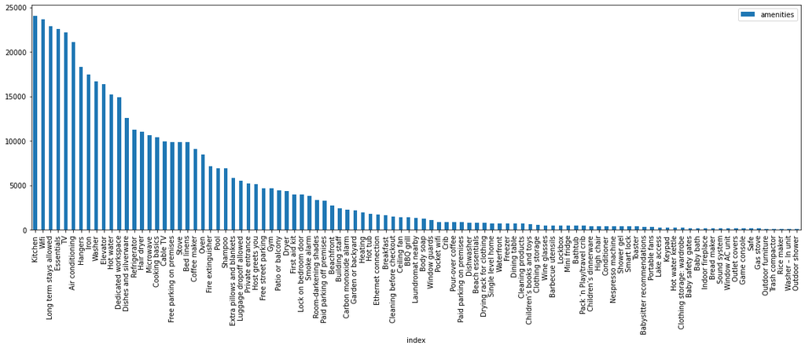

```python
histogram.reset_index().truncate(after=100).set_index('index').plot(kind='bar', figsize=(20, 6))
```

```
                index  cumpercent
50  Laundromat nearby   94.360113
```

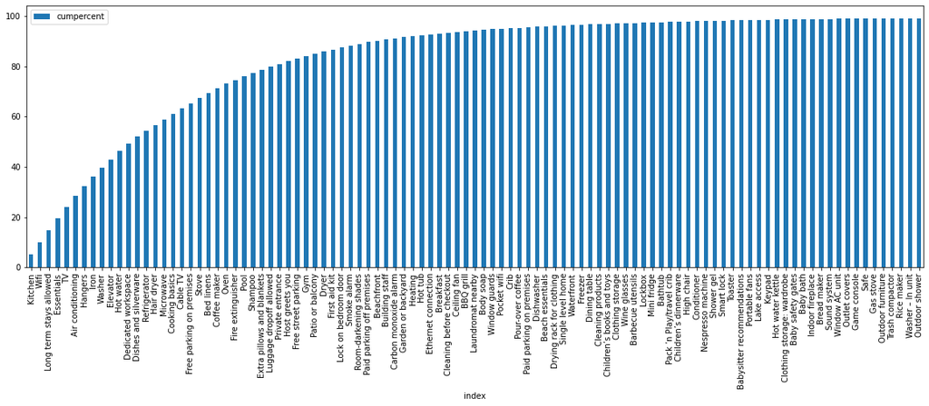

```python
df_cumper=pd.DataFrame(histogram)
total=df_cumper['amenities'].sum()
df_cumper['cumpercent']=df_cumper['amenities'].cumsum()/total*100
print(df_cumper[['cumpercent']].reset_index().iloc[[50]])
df_cumper[['cumpercent']].reset_index().truncate(after=100).set_index('index').plot(kind='bar', figsize=(20, 6))
```

Podemos observar que até a comodidade número 50 em frequência podemos cobrir aproximadamente 94.3% da granularidade do aporte significativo da informação de comodidades ou serviços. Assim pode ser decidido utilizar uma flag de 'Outros' para as 838 comodidades restantes, de menor frequência.

```python
amenities_main_list=histogram.reset_index().truncate(after=50)['index'].tolist()
amenities_main_list
```

```
['Kitchen',
 'Wifi',
 'Long term stays allowed',
 'Essentials',
 'TV',
 'Air conditioning',
 'Hangers',
 'Iron',
 'Washer',
 'Elevator',
 'Hot water',
 'Dedicated workspace',
 'Dishes and silverware',
 'Refrigerator',
 'Hair dryer',
 'Microwave',
 'Cooking basics',
 'Cable TV',
 'Free parking on premises',
 'Stove',
 'Bed linens',
 'Coffee maker',
 'Oven',
 'Fire extinguisher',
 'Pool',
 'Shampoo',
 'Extra pillows and blankets',
 'Luggage dropoff allowed',
 'Private entrance',
 'Host greets you',
 'Free street parking',
 'Gym',
 'Patio or balcony',
 'Dryer',
 'First aid kit',
 'Lock on bedroom door',
 'Smoke alarm',
 'Room-darkening shades',
 'Paid parking off premises',
 'Beachfront',
 'Building staff',
 'Carbon monoxide alarm',
 'Garden or backyard',
 'Heating',
 'Hot tub',
 'Ethernet connection',
 'Breakfast',
 'Cleaning before checkout',
 'Ceiling fan',
 'BBQ grill',
 'Laundromat nearby']
```

### Pré-processamento para a coluna de 'neighbourhood_cleansed':

São identificadas 151 localidades diferentes. De forma similar que com a coluna 'amenities' vamos ver o histograma de frequências dos 50 valores mais frequentes e o percentual cumulativo.

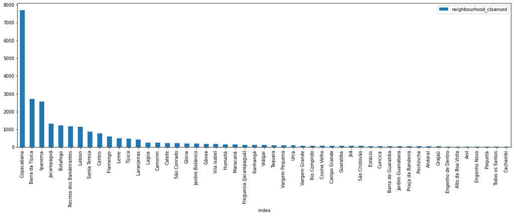

```python
histogram_nei_cle=df_main.neighbourhood_cleansed.value_counts()
histogram_nei_cle.reset_index().truncate(after=50).set_index('index').plot(kind='bar', figsize=(20, 6))
```

```
                index  cumpercent
40  Praça da Bandeira   95.186925
```

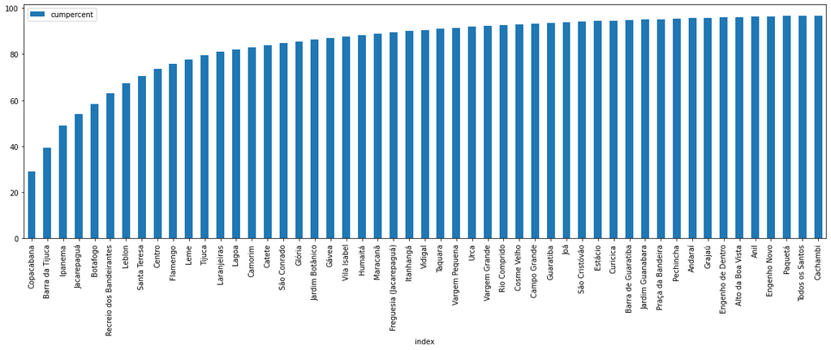

```python
df_cumper=pd.DataFrame(histogram_nei_cle)
total=df_cumper['neighbourhood_cleansed'].sum()
df_cumper['cumpercent']=df_cumper['neighbourhood_cleansed'].cumsum()/total*100
print(df_cumper[['cumpercent']].reset_index().iloc[[40]])
df_cumper[['cumpercent']].reset_index().truncate(after=50).set_index('index').plot(kind='bar', figsize=(20, 6))
```

Podemos observar que até a localidade número 40 em frequência podemos cobrir aproximadamente 95.2% da granularidade do aporte significativo da informação de localização. Assim pode ser decidido utilizar uma flag de 'Outros' para as 111 localizações restantes, de menor frequência.

```python
neighbourhood_cleansed_main_list=histogram_nei_cle.reset_index().truncate(after=40)['index'].tolist()
neighbourhood_cleansed_main_list
```

```
['Copacabana',
 'Barra da Tijuca',
 'Ipanema',
 'Jacarepaguá',
 'Botafogo',
 'Recreio dos Bandeirantes',
 'Leblon',
 'Santa Teresa',
 'Centro',
 'Flamengo',
 'Leme',
 'Tijuca',
 'Laranjeiras',
 'Lagoa',
 'Camorim',
 'Catete',
 'São Conrado',
 'Glória',
 'Jardim Botânico',
 'Gávea',
 'Vila Isabel',
 'Humaitá',
 'Maracanã',
 'Freguesia (Jacarepaguá)',
 'Itanhangá',
 'Vidigal',
 'Taquara',
 'Vargem Pequena',
 'Urca',
 'Vargem Grande',
 'Rio Comprido',
 'Cosme Velho',
 'Campo Grande',
 'Guaratiba',
 'Joá',
 'São Cristóvão',
 'Estácio',
 'Curicica',
 'Barra de Guaratiba',
 'Jardim Guanabara',
 'Praça da Bandeira']
```

### Pré-processamento para a coluna de 'property_type':

São identificados 87 tipos de propriedades diferentes. De forma similar que com a coluna 'neighbourhood_cleansed' vamos ver o histograma de frequências dos 30 valores mais frequentes e o percentual cumulativo.

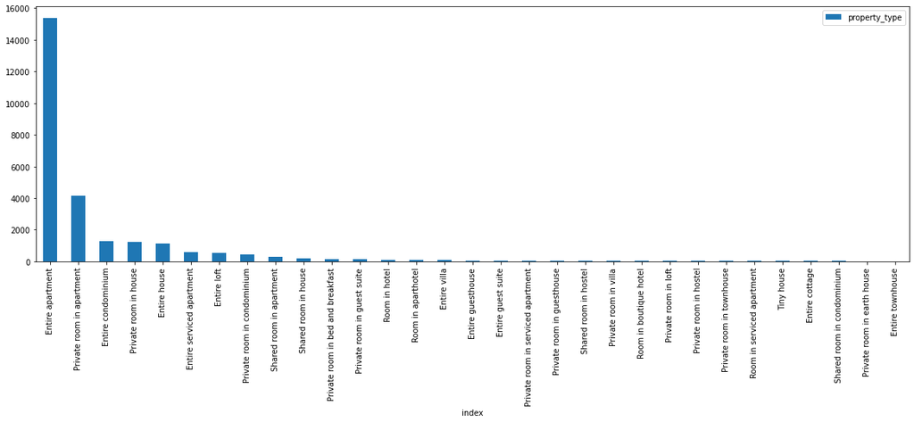

```python
histogram_pro_typ=df_main.property_type.value_counts()
histogram_pro_typ.reset_index().truncate(after=30).set_index('index').plot(kind='bar', figsize=(20, 6))
```

```
                                index  cumpercent
10  Private room in bed and breakfast    95.26207
```

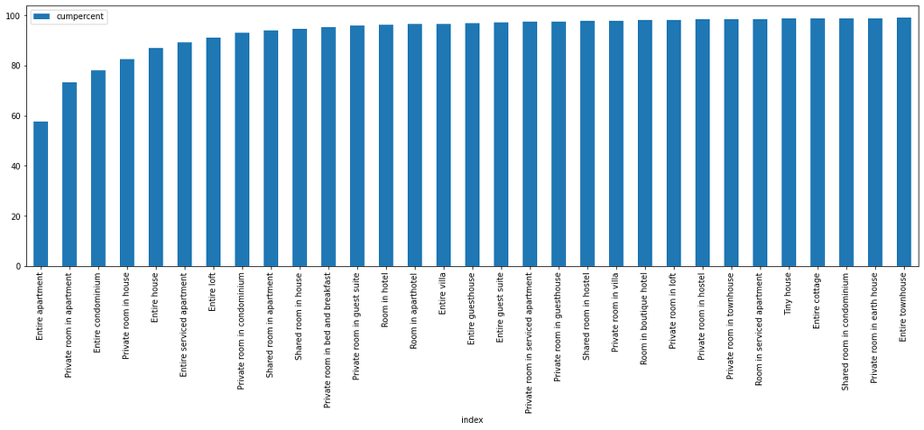

```python
df_cumper=pd.DataFrame(histogram_pro_typ)
total=df_cumper['property_type'].sum()
df_cumper['cumpercent']=df_cumper['property_type'].cumsum()/total*100
print(df_cumper[['cumpercent']].reset_index().iloc[[10]])
df_cumper[['cumpercent']].reset_index().truncate(after=30).set_index('index').plot(kind='bar', figsize=(20, 6))
```

Podemos observar que até o tipo de propriedade número 10 em frequência podemos cobrir aproximadamente 95.3% da granularidade do aporte significativo da informação de tipo de propriedade. Assim pode ser decidido utilizar uma flag de 'Outros' para as 77 localizações restantes, de menor frequência.

```python
property_type_main_list=histogram_pro_typ.reset_index().truncate(after=10)['index'].tolist()
property_type_main_list
```

```
['Entire apartment',
 'Private room in apartment',
 'Entire condominium',
 'Private room in house',
 'Entire house',
 'Entire serviced apartment',
 'Entire loft',
 'Private room in condominium',
 'Shared room in apartment',
 'Shared room in house',
 'Private room in bed and breakfast']
```

### Pré-processamento para a coluna de 'bathrooms_text':

A coluna de bathrooms_text tem informação referente ao número de banheiros, se eles são compartilhados, privativos, ou sem detalhamento. No entanto esta informação está na forma de texto, assim o ideal é identificar regras e padrões simples que permitam extrair estas informações. A continuação se mostra os 52 valores com que este campo está preenchido:

['1 bath', '1.5 baths', '7 baths', '3.5 baths', '3 baths', '2.5 baths', '2 baths', '1 private bath', '4 baths', '5 shared baths', '1 shared bath', '4.5 shared baths', '2 shared baths', '1.5 shared baths', '0 shared baths', '5 baths', '0 baths', '6 baths', 'Shared half-bath', '10 baths', '2.5 shared baths', '4.5 baths', '8 baths', '4 shared baths', '3 shared baths', '6.5 baths', '5.5 baths', '7.5 baths', 'Half-bath', '3.5 shared baths', '7 shared baths', '11.5 baths', '15 baths', '20 shared baths', '20 baths', '6.5 shared baths', '12.5 baths', '11 baths', '12 baths', '15.5 baths', '8.5 baths', '6 shared baths', 'Private half-bath', '10.5 baths', '13 baths', '9 baths', '8.5 shared baths', '9.5 baths', '18 baths', '9 shared baths', '8 shared baths', '5.5 shared baths']

Como podemos ver, podemos utilizar Regular Expressions para extrair os valores numéricos, e pra identificar as flag de Shared e Private. Aqui utilizamos o conceito de Dummy variable, onde para representar as três situações (Share, Private e não informado) só precisamos de dois flags. Também podemos observar que quando não existe um número, em todos os casos corresponde a 'half', então podemos substituir por 0.5. O tratamento de missings será feito em etapas posteriores, no entanto para as flag private e shared, é tratado imediatamente lembrando que estes casos são considerados na variável dummy 'Sim informação'. Isto é: private=0 e shared=0.

```python
df_bathrooms=df_main[['bathrooms_text']].drop_duplicates()
df_bathrooms['number']=df_bathrooms.bathrooms_text.str.extract(r'(\d*\.?\d?)').replace('',0.5)
df_bathrooms['private']=df_bathrooms.bathrooms_text.str.lower().str.contains('priv').fillna(False).astype(int)
df_bathrooms['shared']=df_bathrooms.bathrooms_text.str.lower().str.contains('shar').fillna(False).astype(int)
df_bathrooms.reset_index(drop=True)
```

|  | bathrooms_text | number | private | shared |
| --- | --- | --- | --- | --- |
| 0 | 1 bath | 1 | 0 | 0 |
| 1 | 1.5 baths | 1.5 | 0 | 0 |
| 2 | 7 baths | 7 | 0 | 0 |
| 3 | 3.5 baths | 3.5 | 0 | 0 |
| 4 | 3 baths | 3 | 0 | 0 |
| 5 | 2.5 baths | 2.5 | 0 | 0 |
| 6 | 2 baths | 2 | 0 | 0 |
| 7 | 1 private bath | 1 | 1 | 0 |
| 8 | 4 baths | 4 | 0 | 0 |
| 9 | 5 shared baths | 5 | 0 | 1 |
| 10 | NaN | NaN | 0 | 0 |
| 11 | 1 shared bath | 1 | 0 | 1 |
| 12 | 4.5 shared baths | 4.5 | 0 | 1 |
| 13 | 2 shared baths | 2 | 0 | 1 |
| 14 | 1.5 shared baths | 1.5 | 0 | 1 |
| 15 | 0 shared baths | 0 | 0 | 1 |
| 16 | 5 baths | 5 | 0 | 0 |
| 17 | 0 baths | 0 | 0 | 0 |
| 18 | 6 baths | 6 | 0 | 0 |
| 19 | Shared half-bath | 0.5 | 0 | 1 |
| 20 | 10 baths | 10 | 0 | 0 |
| 21 | 2.5 shared baths | 2.5 | 0 | 1 |
| 22 | 4.5 baths | 4.5 | 0 | 0 |
| 23 | 8 baths | 8 | 0 | 0 |
| 24 | 4 shared baths | 4 | 0 | 1 |
| 25 | 3 shared baths | 3 | 0 | 1 |
| 26 | 6.5 baths | 6.5 | 0 | 0 |
| 27 | 5.5 baths | 5.5 | 0 | 0 |
| 28 | 7.5 baths | 7.5 | 0 | 0 |
| 29 | Half-bath | 0.5 | 0 | 0 |
| 30 | 3.5 shared baths | 3.5 | 0 | 1 |
| 31 | 7 shared baths | 7 | 0 | 1 |
| 32 | 11.5 baths | 11.5 | 0 | 0 |
| 33 | 15 baths | 15 | 0 | 0 |
| 34 | 20 shared baths | 20 | 0 | 1 |
| 35 | 20 baths | 20 | 0 | 0 |
| 36 | 6.5 shared baths | 6.5 | 0 | 1 |
| 37 | 12.5 baths | 12.5 | 0 | 0 |
| 38 | 11 baths | 11 | 0 | 0 |
| 39 | 12 baths | 12 | 0 | 0 |
| 40 | 15.5 baths | 15.5 | 0 | 0 |
| 41 | 8.5 baths | 8.5 | 0 | 0 |
| 42 | 6 shared baths | 6 | 0 | 1 |
| 43 | Private half-bath | 0.5 | 1 | 0 |
| 44 | 10.5 baths | 10.5 | 0 | 0 |
| 45 | 13 baths | 13 | 0 | 0 |
| 46 | 9 baths | 9 | 0 | 0 |
| 47 | 8.5 shared baths | 8.5 | 0 | 1 |
| 48 | 9.5 baths | 9.5 | 0 | 0 |
| 49 | 18 baths | 18 | 0 | 0 |
| 50 | 9 shared baths | 9 | 0 | 1 |
| 51 | 8 shared baths | 8 | 0 | 1 |
| 52 | 5.5 shared baths | 5.5 | 0 | 1 |

## Funções de pré-processamento

Agora que foram definidas as regras de pré-processamento das colunas, prossegue a criação das funções que depois serão acrescentados no processo do modelo. Vale destacar que estas transformações não precisam serem construídas unicamente com o conjunto de treino, pois mesmo em uma amostra aleatória de 70% ou 80% da base total, as features que descrevem aproximadamente o 95% da granularidade se manteriam inalteradas, e o resultado seria exatamente o mesmo. No entanto desde o tratamento de missings em diante sim será necessário utilizar unicamente as informações de um subconjunto de treino.

```python
def select_columns_model(df,columns_model):
    df[columns_model].copy()
    return df[columns_model].copy()
```

```python
def transform_amenities(df,values_list):
    # Separamos a lista em colunas para cada ID
    df_reformated=df[['id']].merge(pd.DataFrame(df.amenities.apply(lambda x: ast.literal_eval(x)).values.tolist()),left_index=True, right_index=True)
    # Transformaçaõ para duas colunas, com id e cada comodidade.
    df_expanded=df_reformated.melt('id', value_name='amenities').drop('variable', axis=1).fillna('Não Informado')
    # Filtro e adição do label 'Outros' para diminuir o numero de features para 50 no metodo de One Hot Encoding
    df_expanded.loc[(df_expanded['amenities'].isin(values_list)==False)&(df_expanded['amenities'].notnull()),'amenities']='Outros'
    # Los missing são codificados na variavel Dummy (Todos os valores iguais a zero)
    counts=df_expanded.groupby('id')['amenities'].value_counts()
    result=counts.unstack(level=-1).add_prefix('amenities_').fillna(0).astype(int).reset_index()
    return df.drop(columns='amenities').merge(result,on='id')
```

```python
def transform_neighbourhood_cleansed(df,values_list):
    df_reduced=df[['id','neighbourhood_cleansed']].copy()
    df_reduced.loc[(df_reduced['neighbourhood_cleansed'].isin(values_list)==False)&(df_reduced['neighbourhood_cleansed'].notnull()),'neighbourhood_cleansed']='Outros'
    counts=df_reduced.groupby('id')['neighbourhood_cleansed'].value_counts()
    result=counts.unstack(level=-1).add_prefix('nei_cle_').fillna(0).astype(int).reset_index()
    return df.drop(columns='neighbourhood_cleansed').merge(result,on='id')
```

```python
def transform_property_type(df,values_list):
    df_reduced=df[['id','property_type']].copy()
    df_reduced.loc[(df_reduced['property_type'].isin(values_list)==False)&(df_reduced['property_type'].notnull()),'property_type']='Outros'
    counts=df_reduced.groupby('id')['property_type'].value_counts()
    result=counts.unstack(level=-1).add_prefix('pro_typ_').fillna(0).astype(int).reset_index()
    return df.drop(columns='property_type').merge(result,on='id')
```

```python
def transform_bathrooms_text(df):
    df_bathrooms=df[['id','bathrooms_text']].copy()
    df_bathrooms['bath_number']=df_bathrooms.bathrooms_text.str.extract(r'(\d*\.?\d?)').replace('',0.5)
    df_bathrooms['bath_number'].fillna(df_bathrooms['bath_number'].mode()[0], inplace=True)
    df_bathrooms['bath_private']=df_bathrooms.bathrooms_text.str.lower().str.contains('priv').fillna(False).astype(int)
    df_bathrooms['bath_shared']=df_bathrooms.bathrooms_text.str.lower().str.contains('shar').fillna(False).astype(int)
    df_bathrooms=df_bathrooms.drop(columns='bathrooms_text')
    return df.drop(columns='bathrooms_text').merge(df_bathrooms,on='id')
```

Finalmente fazer as transformações de tipo, considerando que os booleanos se transformaram em 0 e 1.

```python
def cast_columns(df):
    # cast price to float
    df['price']=df['price'].replace('[\$\,]','',regex=True).astype(float)
    # cast booleans to int
    df[['host_is_superhost','host_has_profile_pic','host_identity_verified']]=df[['host_is_superhost','host_has_profile_pic','host_identity_verified']].replace('f',0).replace('t',1)
    pd.get_dummies(df['room_type'])
    return df
```

## Pré-processamento dos dados e preparação para análises

```python
%%time
df_modelo=select_columns_model(df_main,columns_model)
df_modelo=transform_amenities(df_modelo,amenities_main_list)
df_modelo=transform_neighbourhood_cleansed(df_modelo,neighbourhood_cleansed_main_list)
df_modelo=transform_property_type(df_modelo,property_type_main_list)
df_modelo=transform_bathrooms_text(df_modelo)
df_modelo=cast_columns(df_modelo)
#para a coluna room_type podemos aplicar o One Hot Encoder tradicional
df_modelo=pd.get_dummies(df_modelo,columns=['room_type'])
df_modelo=df_modelo.astype(float)
df_modelo
```

```
Wall time: 2.89 s
```

|  | id | host_is_superhost | host_has_profile_pic | host_identity_verified | accommodates | bedrooms | beds | price | minimum_nights | maximum_nights | ... | pro_typ_Private room in house | pro_typ_Shared room in apartment | pro_typ_Shared room in house | bath_number | bath_private | bath_shared | room_type_Entire home/apt | room_type_Hotel room | room_type_Private room | room_type_Shared room |
| --- | --- | --- | --- | --- | --- | --- | --- | --- | --- | --- | --- | --- | --- | --- | --- | --- | --- | --- | --- | --- | --- |
| 0 | 17878.0 | 1.0 | 1.0 | 1.0 | 5.0 | 2.0 | 2.0 | 221.0 | 5.0 | 180.0 | ... | 0.0 | 0.0 | 0.0 | 1.0 | 0.0 | 0.0 | 1.0 | 0.0 | 0.0 | 0.0 |
| 1 | 24480.0 | 0.0 | 1.0 | 1.0 | 2.0 | 1.0 | 1.0 | 307.0 | 3.0 | 90.0 | ... | 0.0 | 0.0 | 0.0 | 1.0 | 0.0 | 0.0 | 1.0 | 0.0 | 0.0 | 0.0 |
| 2 | 25026.0 | 0.0 | 1.0 | 0.0 | 2.0 | 1.0 | 2.0 | 160.0 | 7.0 | 60.0 | ... | 0.0 | 0.0 | 0.0 | 1.0 | 0.0 | 0.0 | 1.0 | 0.0 | 0.0 | 0.0 |
| 3 | 35636.0 | 1.0 | 1.0 | 1.0 | 2.0 | 1.0 | 1.0 | 273.0 | 2.0 | 89.0 | ... | 0.0 | 0.0 | 0.0 | 1.5 | 0.0 | 0.0 | 1.0 | 0.0 | 0.0 | 0.0 |
| 4 | 35764.0 | 1.0 | 1.0 | 1.0 | 2.0 | 1.0 | 1.0 | 135.0 | 3.0 | 15.0 | ... | 0.0 | 0.0 | 0.0 | 1.0 | 0.0 | 0.0 | 1.0 | 0.0 | 0.0 | 0.0 |
| ... | ... | ... | ... | ... | ... | ... | ... | ... | ... | ... | ... | ... | ... | ... | ... | ... | ... | ... | ... | ... | ... |
| 26610 | 48269503.0 | 0.0 | 1.0 | 0.0 | 1.0 | 1.0 | 1.0 | 94.0 | 1.0 | 365.0 | ... | 0.0 | 0.0 | 0.0 | 0.5 | 1.0 | 0.0 | 0.0 | 0.0 | 1.0 | 0.0 |
| 26611 | 48269534.0 | 0.0 | 1.0 | 1.0 | 6.0 | 2.0 | 3.0 | 141.0 | 1.0 | 1125.0 | ... | 0.0 | 0.0 | 0.0 | 1.0 | 0.0 | 0.0 | 1.0 | 0.0 | 0.0 | 0.0 |
| 26612 | 48270411.0 | 0.0 | 1.0 | 1.0 | 8.0 | 4.0 | 4.0 | 2500.0 | 3.0 | 365.0 | ... | 0.0 | 0.0 | 0.0 | 3.0 | 0.0 | 0.0 | 1.0 | 0.0 | 0.0 | 0.0 |
| 26613 | 48270514.0 | 1.0 | 1.0 | 1.0 | 6.0 | 3.0 | 4.0 | 160.0 | 5.0 | 1125.0 | ... | 0.0 | 0.0 | 0.0 | 2.5 | 0.0 | 0.0 | 1.0 | 0.0 | 0.0 | 0.0 |
| 26614 | 48276004.0 | 0.0 | 1.0 | 1.0 | 8.0 | 2.0 | 4.0 | 316.0 | 1.0 | 365.0 | ... | 0.0 | 0.0 | 0.0 | 1.0 | 0.0 | 0.0 | 1.0 | 0.0 | 0.0 | 0.0 |

26615 rows × 131 columns

```python
feature_cols=df_modelo.columns.drop(['price','id'])
X=df_modelo.loc[:,feature_cols]
y=df_modelo.price
```

```python
X
```

|  | host_is_superhost | host_has_profile_pic | host_identity_verified | accommodates | bedrooms | beds | minimum_nights | maximum_nights | number_of_reviews | review_scores_rating | ... | pro_typ_Private room in house | pro_typ_Shared room in apartment | pro_typ_Shared room in house | bath_number | bath_private | bath_shared | room_type_Entire home/apt | room_type_Hotel room | room_type_Private room | room_type_Shared room |
| --- | --- | --- | --- | --- | --- | --- | --- | --- | --- | --- | --- | --- | --- | --- | --- | --- | --- | --- | --- | --- | --- |
| 0 | 1.0 | 1.0 | 1.0 | 5.0 | 2.0 | 2.0 | 5.0 | 180.0 | 260.0 | 94.0 | ... | 0.0 | 0.0 | 0.0 | 1.0 | 0.0 | 0.0 | 1.0 | 0.0 | 0.0 | 0.0 |
| 1 | 0.0 | 1.0 | 1.0 | 2.0 | 1.0 | 1.0 | 3.0 | 90.0 | 85.0 | 95.0 | ... | 0.0 | 0.0 | 0.0 | 1.0 | 0.0 | 0.0 | 1.0 | 0.0 | 0.0 | 0.0 |
| 2 | 0.0 | 1.0 | 0.0 | 2.0 | 1.0 | 2.0 | 7.0 | 60.0 | 238.0 | 94.0 | ... | 0.0 | 0.0 | 0.0 | 1.0 | 0.0 | 0.0 | 1.0 | 0.0 | 0.0 | 0.0 |
| 3 | 1.0 | 1.0 | 1.0 | 2.0 | 1.0 | 1.0 | 2.0 | 89.0 | 181.0 | 94.0 | ... | 0.0 | 0.0 | 0.0 | 1.5 | 0.0 | 0.0 | 1.0 | 0.0 | 0.0 | 0.0 |
| 4 | 1.0 | 1.0 | 1.0 | 2.0 | 1.0 | 1.0 | 3.0 | 15.0 | 353.0 | 98.0 | ... | 0.0 | 0.0 | 0.0 | 1.0 | 0.0 | 0.0 | 1.0 | 0.0 | 0.0 | 0.0 |
| ... | ... | ... | ... | ... | ... | ... | ... | ... | ... | ... | ... | ... | ... | ... | ... | ... | ... | ... | ... | ... | ... |
| 26610 | 0.0 | 1.0 | 0.0 | 1.0 | 1.0 | 1.0 | 1.0 | 365.0 | 0.0 | NaN | ... | 0.0 | 0.0 | 0.0 | 0.5 | 1.0 | 0.0 | 0.0 | 0.0 | 1.0 | 0.0 |
| 26611 | 0.0 | 1.0 | 1.0 | 6.0 | 2.0 | 3.0 | 1.0 | 1125.0 | 0.0 | NaN | ... | 0.0 | 0.0 | 0.0 | 1.0 | 0.0 | 0.0 | 1.0 | 0.0 | 0.0 | 0.0 |
| 26612 | 0.0 | 1.0 | 1.0 | 8.0 | 4.0 | 4.0 | 3.0 | 365.0 | 0.0 | NaN | ... | 0.0 | 0.0 | 0.0 | 3.0 | 0.0 | 0.0 | 1.0 | 0.0 | 0.0 | 0.0 |
| 26613 | 1.0 | 1.0 | 1.0 | 6.0 | 3.0 | 4.0 | 5.0 | 1125.0 | 0.0 | NaN | ... | 0.0 | 0.0 | 0.0 | 2.5 | 0.0 | 0.0 | 1.0 | 0.0 | 0.0 | 0.0 |
| 26614 | 0.0 | 1.0 | 1.0 | 8.0 | 2.0 | 4.0 | 1.0 | 365.0 | 0.0 | NaN | ... | 0.0 | 0.0 | 0.0 | 1.0 | 0.0 | 0.0 | 1.0 | 0.0 | 0.0 | 0.0 |

26615 rows × 129 columns

```python
y
```

```
0         221.0
1         307.0
2         160.0
3         273.0
4         135.0
          ...
26610      94.0
26611     141.0
26612    2500.0
26613     160.0
26614     316.0
Name: price, Length: 26615, dtype: float64
```

## Separação de treino e teste, e tratamento de missings

```python
X_train, X_test, y_train, y_test = train_test_split(
     X, y, test_size=0.25, random_state=2)
```

Entre as colunas que precisavam de um tratamento de missing, podemos descartar aquelas que foram tratadas via one hot encoding, pois a variável dummy foi utilizada para estes casos. Restando assim as informações referentes a:

- 'host_is_superhost','host_has_profile_pic', 'host_identity_verified','accommodates','bath_number', 'bedrooms','beds','minimum_nights', 'maximum_nights', 'number_of_reviews','review_scores_rating', 'review_scores_accuracy','review_scores_cleanliness', 'review_scores_checkin', 'review_scores_communication', 'review_scores_location','review_scores_value'

Podemos ver que inicialmente, uma boa aproximação que funcionaria para estas colunas seria utilizar a moda (o registro mais frequente.)

```python
Missing_most_frequent=SimpleImputer(missing_values=np.nan, strategy='most_frequent')
```

## Modelagem

Para os modelos de regressão que iremos testar, é importante realizar uma normalização previa para que a otimização da função de custo seja o melhor comportada possível.

```python
scaler = StandardScaler()
```

### Analises de PCA

Um dos métodos de dimensionality reduction mais populares é o PCA, a ideia é encontrar componentes principais que são construídos com superposições lineares das features. Em alguns casos se encontra que pode ser capturado até 99% das informações do dataset em poucas componentes principais, o que leva a um treinamento mais fácil. Em este desafio foi analisado o número de componentes principais necessário para reproduzir 95% das propriedades dos dados.

```python
pca=PCA()
estimators = [('missing_treat',Missing_most_frequent), ('normalization', scaler),('pca',pca)]
pipe_pca = Pipeline(estimators)
```

```python
pipe_pca.fit(X_train,y_train)
```

```
Pipeline(steps=[('missing_treat', SimpleImputer(strategy='most_frequent')),
                ('normalization', StandardScaler()), ('pca', PCA())])
```

```python
pipe_pca[-1].explained_variance_ratio_.cumsum()
```

```
array([0.08210434, 0.12681202, 0.1630353 , 0.19496009, 0.21872787,
       0.23789294, 0.25465406, 0.27015114, 0.2830802 , 0.29589959,
       0.3074109 , 0.31803264, 0.32851441, 0.33870383, 0.34844073,
       0.35803569, 0.36727005, 0.37641974, 0.38530675, 0.39411526,
       0.40286442, 0.41147119, 0.41999932, 0.42848354, 0.43691969,
       0.44528351, 0.45354947, 0.46179942, 0.47001287, 0.47817812,
       0.48629029, 0.4943831 , 0.50245372, 0.51046907, 0.51846929,
       0.52643722, 0.53437272, 0.54230407, 0.55019971, 0.55809356,
       0.56596992, 0.57383477, 0.58168645, 0.5895234 , 0.59735009,
       0.60517034, 0.61298432, 0.62079015, 0.628584  , 0.63637272,
       0.64413007, 0.65186356, 0.65956142, 0.66725186, 0.67489365,
       0.68246806, 0.69000435, 0.69753311, 0.70504645, 0.71248925,
       0.71990885, 0.72728063, 0.73460144, 0.74188725, 0.74908993,
       0.75622858, 0.76323496, 0.77021294, 0.77705669, 0.78383297,
       0.79047282, 0.79696292, 0.80336699, 0.8096918 , 0.81597534,
       0.82199715, 0.82795347, 0.83377197, 0.83956386, 0.84525698,
       0.85088994, 0.85631764, 0.86170538, 0.86707553, 0.87240959,
       0.87751535, 0.88257754, 0.88760144, 0.89258974, 0.89739063,
       0.90216679, 0.90685213, 0.91132741, 0.91574927, 0.9200788 ,
       0.9243761 , 0.92862022, 0.93271047, 0.93669948, 0.9405939 ,
       0.94436081, 0.9481034 , 0.95179885, 0.95532257, 0.95870372,
       0.96202039, 0.96511719, 0.9680916 , 0.97087894, 0.97358801,
       0.97615784, 0.97859027, 0.9808756 , 0.98312615, 0.98528303,
       0.98738549, 0.98940681, 0.99119725, 0.9929077 , 0.9945457 ,
       0.99603248, 0.9974746 , 0.99886246, 0.99973259, 1.        ,
       1.        , 1.        , 1.        , 1.        ])
```

Daqui podemos ver que precisamos de cerca de 105 de 129 features para capturar 95% do comportamento dos dados, assim que não teria uma boa relação entre features desconsideradas e informação perdida. Isso pode acontecer porque os dados têm alta variância em todas as possíveis direções no hiper espaço de 129 dimensões. Isso é comum em sistemas com comportamentos fortemente aleatórios. No entanto isso também pode acontecer porque os padrões de comportamento dos dados são não lineares. Nesse caso esperamos que uma regressão linear seja muito próxima de um hiper plano com valor constante igual a média dos preços

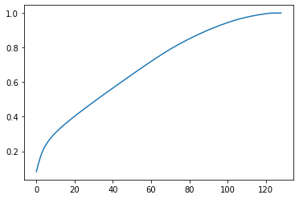

```python
plt.plot(pipe_pca[-1].explained_variance_ratio_.cumsum())
```

### Modelo 1: LinearRegression

Primeiro utilizaremos uma regressão linear pela sua simplicidade e rapidez de cálculo. Além de poder ver se o resultado é coerente com o análises de PCA. Foi escolhido o estimador LinearRegression.

```python
lr=LinearRegression()
estimators = [('missing_treat',Missing_most_frequent), ('normalization', scaler),('regression',lr)]
pipe_lr = Pipeline(estimators)
```

```python
%%time
#Treinamento do modelo
pipe_lr.fit(X_train,y_train)
```

```
Wall time: 363 ms
```

```
Pipeline(steps=[('missing_treat', SimpleImputer(strategy='most_frequent')),
                ('normalization', StandardScaler()),
                ('regression', LinearRegression())])
```

```python
# Calculo de R^2
r2_score(y_test, pipe_lr.predict(X_test))
```

```
-0.0010204808119433917
```

Como podemos ver o R^2 é muito próximo de zero, isto é, um hiper plano com valor constante igual ao preço médio. Assim os próximos métodos vão procurar padrões não lineares.

```python
#Forma equivalente de calcular R^2
pipe_lr.score(X_test,y_test)
```

```
-0.0010204808119433917
```

```python
#salvando o resultado das prediçõoes
y_pred_lr=pipe_lr.predict(X_test)
```

### Modelo 2: SVM

O próximo método permite encontrar correlações não lineares. Embora é um método bastante poderoso, o tempo de treinamento costuma ser bem grande, além disso ele pode nos levar a overfitting o que faz necessário a determinação de alguns hiper parâmetros para fazer o modelo mais conservador. Foi escolhido os kernel 'rbf' por ser mais generais (Quase que qualquer comportamento pode ser descrito com uma superposição de funções gaussianas). O estimador SVR é treinado para minimizar a função de costo ε-insensitive. Para encontrar os hiper parâmetros que produzam o melhor resultado, acostuma ser utilizado o método de GridSearch (tentar com combinações de parâmetros e selecionar o melhor) onde para determinar o score se utiliza o método de CrossValidation (Se faz o treinamento com subgrupos diferentes dos X_train e se testa no subgrupo restante, em diferentes combinações). Dado o tempo que leva para realizar esta otimização dos hiper parâmetros via GridSearchCV, é apresentado neste notebook o resultado da regressão com os parâmetros que forma encontrados como ótimos por esta metodologia. Nas próximas técnicas de modelagem que tem um tempo de treinamento menor, é apresentado, a modo de exemplo, o uso do GridSearchCV para á otimização dos hiper parâmetros.

```python
svr=SVR(C=100000,gamma=0.01)
```

```python
estimators = [('missing_treat',Missing_most_frequent), ('normalization', scaler),('regression',svr)]
pipe = Pipeline(estimators)
```

```python
%%time
pipe.fit(X_train, y_train)
```

```
Wall time: 49min 59s
```

```
Pipeline(steps=[('missing_treat', SimpleImputer(strategy='most_frequent')),
                ('normalization', StandardScaler()),
                ('regression', SVR(C=100000, gamma=0.01))])
```

```python
%%time
pipe.score(X_test,y_test)
```

```
Wall time: 16.3 s
```

```
0.31665292364307707
```

O resultado obtido para R^2 é muito bom, no entanto o tempo de treinamento é alto demais. Vamos ver o resultado com um método similar mas que usualmente tem um tempo de treinamento menor.

```python
#salvando o resultado das prediçõoes
y_pred_svr=pipe.predict(X_test)
```

### Modelo 3: Kernel Ridge

O modelo de Kernel Ridge com kernel='rbf' é similar ao SVR, mas a função de custo a ser minimizada é a função de Ridge, que é a MSE com regularização L2. Usualmente este método é muito mais rapido do que o SVR.

```python
from sklearn.kernel_ridge import KernelRidge
svr=KernelRidge(kernel='rbf',alpha=0.8)
estimators = [('missing_treat',Missing_most_frequent), ('normalization', scaler),('regression',svr)]
pipe = Pipeline(estimators)
```

```python
%%time
param_grid = {'regression__gamma' : [0.005,0.01,0.05]}
search = GridSearchCV(pipe, param_grid, cv=5).fit(X_train, y_train)
```

```
Wall time: 11min 20s
```

```python
pd.set_option('display.max_colwidth', None)
pd.DataFrame(search.cv_results_)[['params','rank_test_score']]
```

|  | params | rank_test_score |
| --- | --- | --- |
| 0 | {'regression__gamma': 0.005} | 3 |
| 1 | {'regression__gamma': 0.01} | 1 |
| 2 | {'regression__gamma': 0.05} | 2 |

```python
%%time
search.score(X_test,y_test)
```

```
Wall time: 2.62 s
```

```
0.2653655286344043
```

Vemos que o R^2 é inferior ao obtido com o SVR, mas o tempo de modelagem também é menor, assim, se precisasemos escolher dentre estes dois, o método de Kernel Ridge seria mais interessante se se tem prioridade sobre velocidade em um cenario que precisa muito retreinamento, e o SVR seria melhor se a prioridade é o fit com os dados.

```python
#salvando o resultado das prediçõoes
y_pred_kr=search.predict(X_test)
```

```python
%%time
#Avaliação para comparação de tempo de treino
svr=KernelRidge(kernel='rbf',alpha=0.8,gamma=0.01)
estimators = [('missing_treat',Missing_most_frequent), ('normalization', scaler),('regression',svr)]
pipe = Pipeline(estimators)
pipe.fit(X_train, y_train)
```

```
Wall time: 1min 5s
```

```
Pipeline(steps=[('missing_treat', SimpleImputer(strategy='most_frequent')),
                ('normalization', StandardScaler()),
                ('regression',
                 KernelRidge(alpha=0.8, gamma=0.01, kernel='rbf'))])
```

### Modelo 4: XGBoost

Possivelmente uns dos melhores métodos para regressão não linear é o XGBoost. Com arvores de decisão sendo construidas por trás, este método costuma ser muito mais rapido e ter um ótimo comportamento de fit com os dados. Mas também é muito propenso a overfitting. Por isso foi utilizado o GridSearchCV

```python
xgb= XGBRegressor(objective='reg:tweedie',max_depth=7,reg_lambda=50,reg_alpha=50)
estimators = [('missing_treat',Missing_most_frequent), ('normalization', scaler),('regression',xgb)]
pipe = Pipeline(estimators)
```

```python
%%time
param_grid = {'regression__max_delta_step':[1,10,100],'regression__min_child_weight':[1,10,50]}
search = GridSearchCV(pipe, param_grid, cv=5).fit(X_train, y_train)
```

```
Wall time: 1min 41s
```

```python
pd.set_option('display.max_colwidth', None)
pd.DataFrame(search.cv_results_)[['params','rank_test_score','mean_test_score']]
```

|  | params | rank_test_score | mean_test_score |
| --- | --- | --- | --- |
| 0 | {'regression__max_delta_step': 1, 'regression__min_child_weight': 1} | 9 | 0.243569 |
| 1 | {'regression__max_delta_step': 1, 'regression__min_child_weight': 10} | 6 | 0.257398 |
| 2 | {'regression__max_delta_step': 1, 'regression__min_child_weight': 50} | 5 | 0.258669 |
| 3 | {'regression__max_delta_step': 10, 'regression__min_child_weight': 1} | 3 | 0.261348 |
| 4 | {'regression__max_delta_step': 10, 'regression__min_child_weight': 10} | 1 | 0.262378 |
| 5 | {'regression__max_delta_step': 10, 'regression__min_child_weight': 50} | 7 | 0.253463 |
| 6 | {'regression__max_delta_step': 100, 'regression__min_child_weight': 1} | 3 | 0.261348 |
| 7 | {'regression__max_delta_step': 100, 'regression__min_child_weight': 10} | 1 | 0.262378 |
| 8 | {'regression__max_delta_step': 100, 'regression__min_child_weight': 50} | 7 | 0.253463 |

```python
search.score(X_test,y_test)
```

```
0.35073787589637284
```

Assim o modelo de XGBoost mostra ser o melhor dos modelos testados, com um tempo de treino curto e um excelente comportamento ao prever dados novos, com R^2=0.35.

```python
#salvando o resultado das prediçõoes
y_pred_XG=search.predict(X_test)
```

```python
%%time
#Avaliação para comparação de tempo de treino
xgb= XGBRegressor(objective='reg:tweedie',max_depth=7,reg_lambda=50,reg_alpha=50,max_delta_step=10,min_child_weight=10)
estimators = [('missing_treat',Missing_most_frequent), ('normalization', scaler),('regression',xgb)]
pipe = Pipeline(estimators)
pipe.fit(X_train, y_train)
```

```
Wall time: 2.63 s
```

```
Pipeline(steps=[('missing_treat', SimpleImputer(strategy='most_frequent')),
                ('normalization', StandardScaler()),
                ('regression',
                 XGBRegressor(base_score=0.5, booster='gbtree',
                              colsample_bylevel=1, colsample_bynode=1,
                              colsample_bytree=1, gamma=0, gpu_id=-1,
                              importance_type='gain',
                              interaction_constraints='',
                              learning_rate=0.300000012, max_delta_step=10,
                              max_depth=7, min_child_weight=10, missing=nan,
                              monotone_constraints='()', n_estimators=100,
                              n_jobs=8, num_parallel_tree=1,
                              objective='reg:tweedie', random_state=0,
                              reg_alpha=50, reg_lambda=50,
                              scale_pos_weight=None, subsample=1,
                              tree_method='exact', validate_parameters=1,
                              verbosity=None))])
```

## Analises de residuos

A continuação vamos fazer o analises de residuos para ver quao bem os modelos preveem o preço em dados novos.

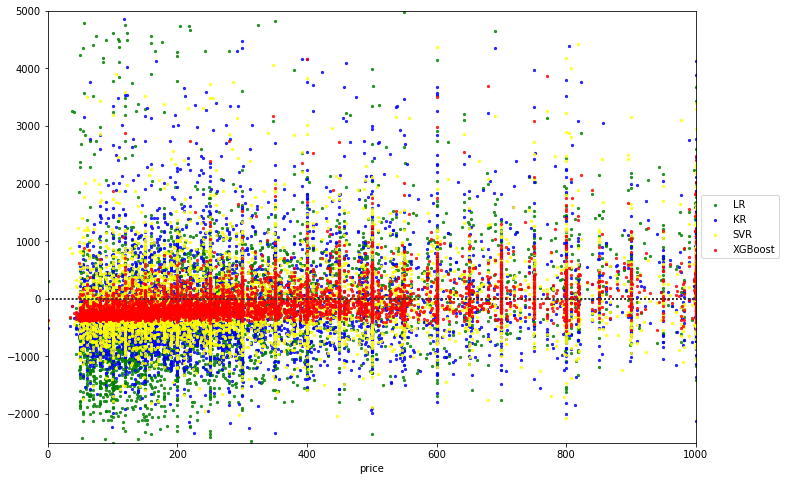

```python
# Creating a new axes with specified dimensions and some kwargs
plott=plt.axes((0,0,1.5,1.5))
plott.set_ylim(-2500,5000)
plott.set_xlim(0,1000)
residplot(x=y_test, y=y_pred_lr,scatter_kws={'s':5},label='LR',color='green')
residplot(x=y_test, y=y_pred_kr,scatter_kws={'s':5},label='KR',color='blue')
residplot(x=y_test, y=y_pred_svr,scatter_kws={'s':5},label='SVR',color='yellow')
residplot(x=y_test, y=y_pred_XG,scatter_kws={'s':5},label='XGBoost',color='red')
plott.legend(loc='center left', bbox_to_anchor=(1, 0.5))
# legend = plott.legend(loc='upper center', shadow=True, fontsize='x-large')
# legend.get_frame().set_facecolor('C0')
plt.show()
```

Podemos observar que o método de LR é o que tem uma disperção maior nos residuos, já o KR se comporta levemente melhor, o SVR traz uma disperção menor dos residuos que os anteriores. No entanto é o XGBoost quem mostra os residuos mais concentrados, o que nos indica que teve um aprendizado ou um fit melhor dos dados, e que é um melhor previsor.

## Comparação das métricas dos modelos e conclusão

Vamos fazer a comparação das principais métricas dos modelos.

```python
pd.DataFrame([[label,explained_variance_score(y_test, y_prediction),mean_absolute_error(y_test, y_prediction),
  mean_squared_error(y_test, y_prediction),r2_score(y_test, y_prediction),time] for label,y_prediction,time
 in [('LR',y_pred_lr,'317 ms'),('SVR',y_pred_svr,'50 min'),('KR',y_pred_kr,'1 min'),('XGBoost',y_pred_XG,'2.6 s')]],columns=['Método','Explained Variance','Erro absoluto medio','Erro Quadrado medio','R^2','Tempo de treinamento'])
```

|  | Método | Explained Variance | Erro absoluto medio | Erro Quadrado medio | R^2 | Tempo de treinamento |
| --- | --- | --- | --- | --- | --- | --- |
| 0 | LR | 0.000092 | 837.382338 | 8.389618e+06 | -0.001020 | 317 ms |
| 1 | SVR | 0.316663 | 631.347072 | 5.727176e+06 | 0.316653 | 50 min |
| 2 | KR | 0.265790 | 743.561847 | 6.157019e+06 | 0.265366 | 1 min |
| 3 | XGBoost | 0.351424 | 392.714108 | 5.441508e+06 | 0.350738 | 2.6 s |

Podemos ver que o XGBoost foi o modelo que teve as melhores métricas, e o tempo de treino é muito bom comparando com os outros métodos. Assim com os modelos de XGBoost conseguimos explicar o 35% das variações nos dados. Um resultado excelente quando consideramos, como mostrou o PCA, que os dados são robustos no hiper espaço. Embora o SVR também teve bons resultados, o tempo de treino é muito grande, limitando os cenários nos quais seria uma solução viável. Assim, para o presente desafio, o modelo a ser escolhido é o treinado com XGBoost, com os resultados mostrados ao longo deste Notebbok.